# AllLife Credit Card Customer Segmentation

**Background:** AllLife Bank wants to focus on its credit card customer base in the next financial year. They have been advised by their marketing research team, that the penetration in the market can be improved. Based on this input, the Marketing team proposes to run personalised campaigns to target new customers as well as upsell to existing customers. Another insight from the market research was that the customers perceive the support services of the bank poorly. Based on this, the Operations team wants to upgrade the service delivery model, to ensure that customers queries are resolved faster. Head of Marketing and Head of Delivery both decide to reach out to the Data Science team for help.

**Objective:** To identify different segments in the existing customer based on their spending patterns as well as past interaction with the bank.

**Key Questions:**

1. How many different segments of customers are there?
2. How are these segments different from each other?
3. What are your recommendations to the bank on how to better market to and service these customers?

**Data Description:** Data is of various customers of a bank with their credit limit, the total number of credit cards the customer has, and different channels through which customer has contacted the bank for any queries, different channels include visiting the bank, online and through a call centre.

# Loading data

```python
#importing necessary libraries
import pandas as pd
import numpy as np
import seaborn as sns
import matplotlib.pyplot as plt
import matplotlib.cm as cm

from scipy.spatial.distance import cdist, pdist
from scipy.cluster.hierarchy import dendrogram, linkage, cophenet, fcluster
from sklearn.preprocessing import StandardScaler
from sklearn.cluster import KMeans
from sklearn.metrics import silhouette_score, silhouette_samples
```

```python
df = pd.read_excel('Credit Card Customer Data.xlsx', index_col='Sl_No')
```

```python
df
```

| Sl_No | Customer Key | Avg_Credit_Limit | Total_Credit_Cards | Total_visits_bank | Total_visits_online | Total_calls_made |
| --- | --- | --- | --- | --- | --- | --- |
| 1 | 87073 | 100000 | 2 | 1 | 1 | 0 |
| 2 | 38414 | 50000 | 3 | 0 | 10 | 9 |
| 3 | 17341 | 50000 | 7 | 1 | 3 | 4 |
| 4 | 40496 | 30000 | 5 | 1 | 1 | 4 |
| 5 | 47437 | 100000 | 6 | 0 | 12 | 3 |
| ... | ... | ... | ... | ... | ... | ... |
| 656 | 51108 | 99000 | 10 | 1 | 10 | 0 |
| 657 | 60732 | 84000 | 10 | 1 | 13 | 2 |
| 658 | 53834 | 145000 | 8 | 1 | 9 | 1 |
| 659 | 80655 | 172000 | 10 | 1 | 15 | 0 |
| 660 | 80150 | 167000 | 9 | 0 | 12 | 2 |

660 rows × 6 columns

Dataset includes data from 660 customers.

```python
#dropping the customer key columns as it is a unique identifier and does not hold any statistical significance
df.drop('Customer Key',axis=1,inplace=True)
```

```python
df.info()
```

```
<class 'pandas.core.frame.DataFrame'>
Int64Index: 660 entries, 1 to 660
Data columns (total 5 columns):
 #   Column               Non-Null Count  Dtype
---  ------               --------------  -----
 0   Avg_Credit_Limit     660 non-null    int64
 1   Total_Credit_Cards   660 non-null    int64
 2   Total_visits_bank    660 non-null    int64
 3   Total_visits_online  660 non-null    int64
 4   Total_calls_made     660 non-null    int64
dtypes: int64(5)
memory usage: 30.9 KB
```

**Observations**

- We have 660 rows and 5 columns in the data
- All 5 variables are numeric and of integer type.

```python
df.describe()
```

|  | Avg_Credit_Limit | Total_Credit_Cards | Total_visits_bank | Total_visits_online | Total_calls_made |
| --- | --- | --- | --- | --- | --- |
| count | 660.000000 | 660.000000 | 660.000000 | 660.000000 | 660.000000 |
| mean | 34574.242424 | 4.706061 | 2.403030 | 2.606061 | 3.583333 |
| std | 37625.487804 | 2.167835 | 1.631813 | 2.935724 | 2.865317 |
| min | 3000.000000 | 1.000000 | 0.000000 | 0.000000 | 0.000000 |
| 25% | 10000.000000 | 3.000000 | 1.000000 | 1.000000 | 1.000000 |
| 50% | 18000.000000 | 5.000000 | 2.000000 | 2.000000 | 3.000000 |
| 75% | 48000.000000 | 6.000000 | 4.000000 | 4.000000 | 5.000000 |
| max | 200000.000000 | 10.000000 | 5.000000 | 15.000000 | 10.000000 |

**Observations**

- The average credit limit ranges from 3,000 to 200,000 with a median value of 18,000.
- The total number of credit cards per customer ranges from 1 to 10 with a median value of 5.
- The total number of visits to the bank ranges from 0 to 5 with a median value of 2.
- The total number of visits online ranges from 0 to 15 with a median value of 2.
- The total number of calls made ranges from 0 to 10 with a median value of 3.

```python
df.isna().sum()
```

```
Avg_Credit_Limit       0
Total_Credit_Cards     0
Total_visits_bank      0
Total_visits_online    0
Total_calls_made       0
dtype: int64
```

There are no missing values in the data set.

# EDA

## Univariate analysis

```python
# Function that will create boxplot and histogram for any input numerical variable.
# This function takes the numerical column as the input and returns the boxplots and histograms for the variable.
def histogram_boxplot(feature, figsize=(15,7), bins = None):
    """ Boxplot and histogram combined
    feature: 1-d feature array
    figsize: size of fig (default (15,7))
    bins: number of bins (default None / auto)
    """
    f2, (ax_box2, ax_hist2) = plt.subplots(nrows = 2, # Number of rows of the subplot grid= 2
                                           sharex = True, # x-axis will be shared among all subplots
                                           gridspec_kw = {"height_ratios": (.25, .75)},
                                           figsize = figsize
                                           ) # creating the 2 subplots
    sns.boxplot(x=feature, data=df, ax=ax_box2, showmeans=True, color='violet') # boxplot will be created and a star will indicate the mean value of the column
    sns.histplot(x=feature, data=df, kde=False, ax=ax_hist2, bins=bins,palette="winter") if bins else sns.histplot(x=feature, data=df, kde=False, ax=ax_hist2) # For histogram
    ax_hist2.axvline(df[feature].mean(), color='green', linestyle='--') # Add mean to the histogram
    ax_hist2.axvline(df[feature].median(), color='black', linestyle='-') # Add median to the histogram
```

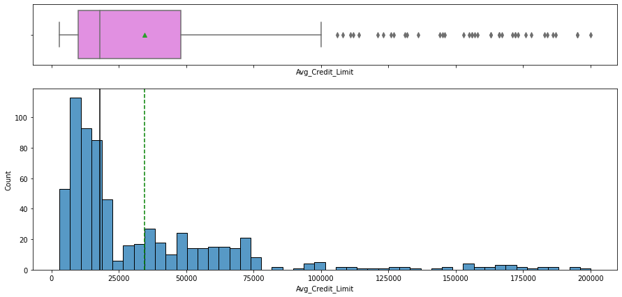

```python
# Observations on Average credit limit
histogram_boxplot("Avg_Credit_Limit", bins=50)
```

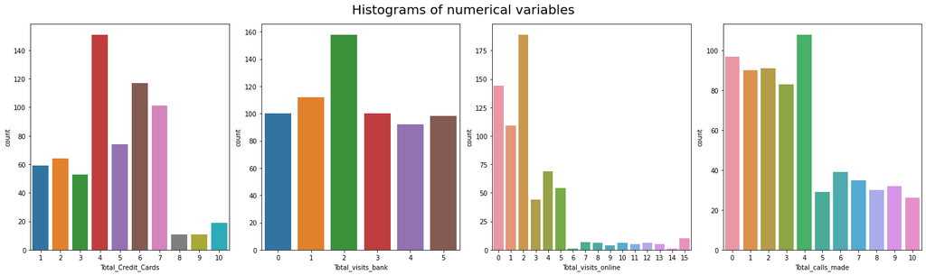

```python
fig, axes = plt.subplots(1, 4,  figsize=(20, 6))
fig.suptitle('Histograms of numerical variables', fontsize=20)
for i in range(4):
    sns.countplot(ax=axes[i],x=df.iloc[:,i+1])
fig.tight_layout(pad=1)
```

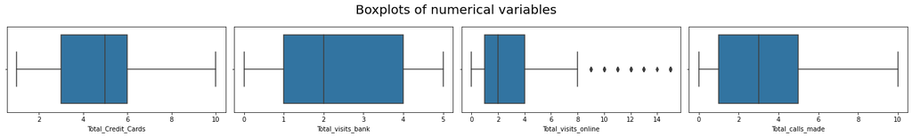

```python
fig, axes = plt.subplots(1, 4,  figsize=(20, 3))
fig.suptitle('Boxplots of numerical variables', fontsize=20)
for i in range(4):
    sns.boxplot(ax=axes[i],x=df.iloc[:,i+1])
fig.tight_layout(pad=1)
```

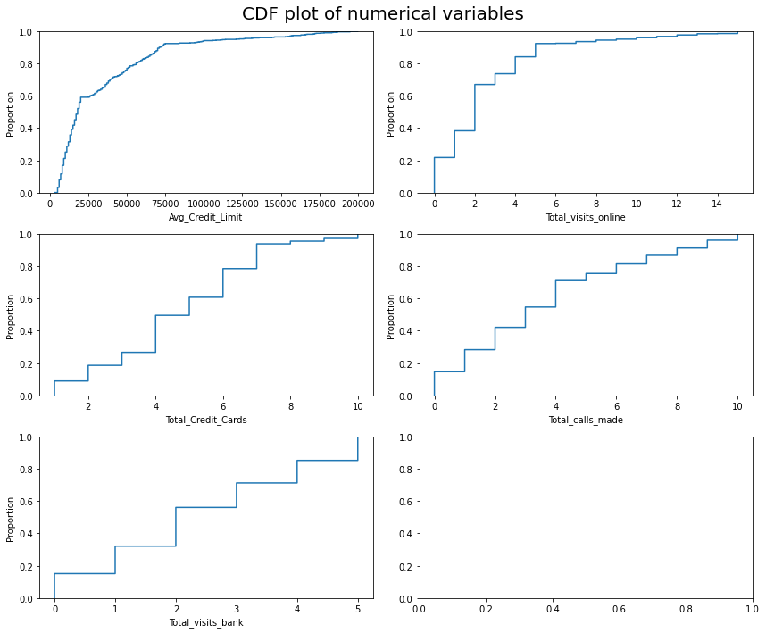

```python
# Cumulative distribution function plots
fig, axes = plt.subplots(3, 2,  figsize=(12, 10))
fig.suptitle('CDF plot of numerical variables', fontsize=20)
for i in range(3):
    sns.ecdfplot(ax=axes[i][0],x=df.iloc[:,i])
for j in range(3, 5):
    sns.ecdfplot(ax=axes[j-3][1],x=df.iloc[:,j])
fig.tight_layout(pad=1)
```

**Observations**

- The average credit limit follows a right skewed distribution with a mean value of 34,574 and a median value of 18,000. Although the box plot shows outliers, these are real numbers and do not need to be treated.
- The CDF plot for the average credit limit shows 3 different slope regimes with 2 sharp elbows.
- Most of customers own a total of 4 credit cards and make 2 visits to the bank.
- Most often, customers do not exceed 5 visits online and make rarely more than 4 calls.

## Bivariate analysis

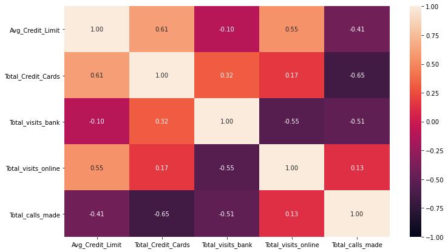

```python
plt.figure(figsize=(12,7))
sns.heatmap(df.corr(),annot=True, fmt='.2f', vmin=-1);
```

**Observation**

Variables are highly correlated with each other.

- The average credit limit is positively correlated with the number of credit cards and visits online.
- The number of calls made is negatively correlated with the credit limit, number of credit cards and visits to the bank.
- The number of visits to the bank is negatively correlated with the number of visits online. This means that customers decide either to deal with the bank in person at the branch or through internet banking.

### Pairplots

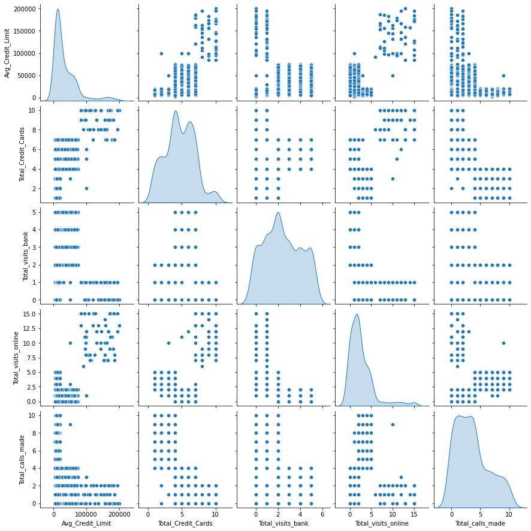

```python
sns.pairplot(df,diag_kind="kde");
```

**Observations**

- The average credit limit and number of credit cards seem to follow trimodal distributions.
- The number of calls to the bank, visits to the bank and online seem to follow bimodal distributions

# K means clustering

### Scaling the dataset

```python
# Scaling the data set before clustering
scaler=StandardScaler()
subset=df.copy()
subset_scaled=scaler.fit_transform(subset)
```

```python
#Creating a dataframe from the scaled data above
subset_scaled_df=pd.DataFrame(subset_scaled,columns=subset.columns)
```

```python
subset_scaled_df.head()
```

|  | Avg_Credit_Limit | Total_Credit_Cards | Total_visits_bank | Total_visits_online | Total_calls_made |
| --- | --- | --- | --- | --- | --- |
| 0 | 1.740187 | -1.249225 | -0.860451 | -0.547490 | -1.251537 |
| 1 | 0.410293 | -0.787585 | -1.473731 | 2.520519 | 1.891859 |
| 2 | 0.410293 | 1.058973 | -0.860451 | 0.134290 | 0.145528 |
| 3 | -0.121665 | 0.135694 | -0.860451 | -0.547490 | 0.145528 |
| 4 | 1.740187 | 0.597334 | -1.473731 | 3.202298 | -0.203739 |

### Elbow method

```
Number of Clusters: 1 	Average Distortion: 2.0069222262503614
Number of Clusters: 2 	Average Distortion: 1.4571553548514269
Number of Clusters: 3 	Average Distortion: 1.1466276549150365
Number of Clusters: 4 	Average Distortion: 1.0463825294774465
Number of Clusters: 5 	Average Distortion: 0.9908683849620168
Number of Clusters: 6 	Average Distortion: 0.9515723980470872
Number of Clusters: 7 	Average Distortion: 0.9095950026993534
Number of Clusters: 8 	Average Distortion: 0.8894589591354081
Number of Clusters: 9 	Average Distortion: 0.8640223995333983
Number of Clusters: 10 	Average Distortion: 0.8477009856491604
```

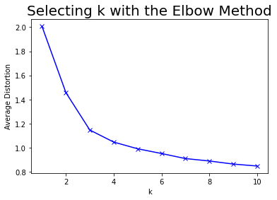

```python
clusters=range(1,11)
meanDistortions=[]

for k in clusters:
    model=KMeans(n_clusters=k)
    model.fit(subset_scaled_df)
    prediction=model.predict(subset_scaled_df)
    distortion=sum(np.min(cdist(subset_scaled_df, model.cluster_centers_, 'euclidean'), axis=1)) / subset_scaled_df.shape[0]

    meanDistortions.append(distortion)

    print('Number of Clusters:', k, '\tAverage Distortion:', distortion)

plt.plot(clusters, meanDistortions, 'bx-');
plt.xlabel('k')
plt.ylabel('Average Distortion')
plt.title('Selecting k with the Elbow Method', fontsize=20)
```

The appropriate value of k from the elbow curve above seems to be 3.

### Applying K means algorithm with 3 clusters

```python
kmeans = KMeans(n_clusters=3, random_state=0)
kmeans.fit(subset_scaled_df)
```

```
KMeans(n_clusters=3, random_state=0)
```

```python
df_Kmean = df.copy()
```

```python
df_Kmean['K_means_segments'] = kmeans.labels_
```

```python
# Rearranging cluster numbering based on average credit limit ranking
df_Kmean['K_means_segments'] = df_Kmean['K_means_segments'].map({0:2, 1:1, 2:3})
K_means_clusters = df_Kmean.groupby('K_means_segments').mean()
K_means_clusters['count_in_each_segment'] = df_Kmean.groupby('K_means_segments')['Avg_Credit_Limit'].count().values
K_means_clusters
```

| K_means_segments | Avg_Credit_Limit | Total_Credit_Cards | Total_visits_bank | Total_visits_online | Total_calls_made | count_in_each_segment |
| --- | --- | --- | --- | --- | --- | --- |
| 1 | 12174.107143 | 2.410714 | 0.933036 | 3.553571 | 6.870536 | 224 |
| 2 | 33782.383420 | 5.515544 | 3.489637 | 0.981865 | 2.000000 | 386 |
| 3 | 141040.000000 | 8.740000 | 0.600000 | 10.900000 | 1.080000 | 50 |

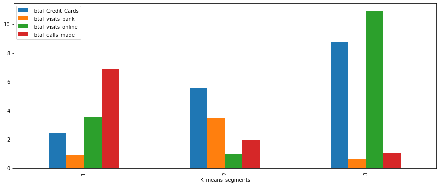

```python
K_means_clusters.iloc[:,1:-1].plot.bar(figsize=(15,6));
```

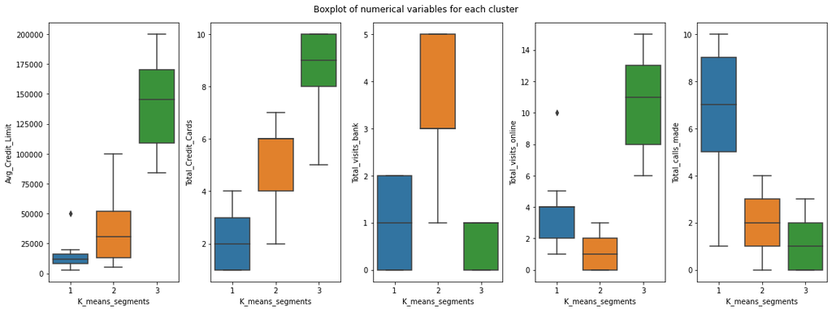

```python
fig, axes = plt.subplots(1, 5,  figsize=(16, 6))
fig.suptitle('Boxplot of numerical variables for each cluster')
for i in range(5):
    sns.boxplot(ax=axes[i],y=df_Kmean.iloc[:,i],x=df_Kmean['K_means_segments'])
fig.tight_layout(pad=1)
```

**Insights**

Customers can be grouped into 3 clusters.

- Cluster 1 (224 customers) :
  - The credit limit for this group of customers is in the low range with an average of 12,174.
  - The number of credit card for this group of customers is low with most customers having between 1 and 3 credit cards.
  - The number of visits to the bank is low with customers making no more than 2 visits to the bank.
  - The number of visits online remains limited with most customers making between 2 and 4 visits online.
  - The number of phone calls is high with 75 % of customers in this group making at least 5 phone calls.
- Clusters 2 (386 customers) :
  - The credit limit for this group of customers is in the mid range with an average of 33,782.
  - The number of credit card for this group of customers is in the mid range with most customers having between 4 and 6 credit cards.
  - The number of visits to the bank is high with most customers making between 3 and 5 visits to the bank.
  - On the contrary, the number of visits online is low with most customers making fewer than 2 visits online.
  - The number of phone calls remains low with most customers making between 1 and 3 phone calls.
- Cluster 3 (50 customers):
  - The credit limit for this group of customers is very high with an average of 141,040.
  - The number of credit card for this group of customers is also high with 75% of customers in this group having at least 8 credit cards.
  - The number of visits to the bank is low not exceeding 1 visit to the bank.
  - On the contrary, the number of visits online is very high with 75% of customers making at least 8 visits online.
  - The number of phone calls remains low with most customers making less than 2 phone calls.

# Hierarchical Clustering

### Distance metrics and linkage methods

```python
# The cophenetic correlation index is a measure of the correlation between the distance of points in feature space and
# distance on dendrogram. The closer it is to 1, the better is the clustering
distance_metrics = ['euclidean','chebyshev','mahalanobis','cityblock']
linkage_methods = ['single', 'complete', 'average', 'weighted']
high_cophenet_corr = 0
high_dm_lm = [0,0]
for dm in distance_metrics:
    for lm in linkage_methods:
        Z = linkage(subset_scaled_df, metric=dm, method=lm)
        c, coph_dists = cophenet(Z , pdist(subset_scaled_df))
        print('Cophenetic correlation for distance metrics {} and linkage method {} is {:.3f}'.format(dm,lm,c))
        if high_cophenet_corr < c:
            high_cophenet_corr = c
            high_dm_lm[0] = dm
            high_dm_lm[1] = lm
```

```
Cophenetic correlation for distance metrics euclidean and linkage method single is 0.739
Cophenetic correlation for distance metrics euclidean and linkage method complete is 0.860
Cophenetic correlation for distance metrics euclidean and linkage method average is 0.898
Cophenetic correlation for distance metrics euclidean and linkage method weighted is 0.886
Cophenetic correlation for distance metrics chebyshev and linkage method single is 0.738
Cophenetic correlation for distance metrics chebyshev and linkage method complete is 0.853
Cophenetic correlation for distance metrics chebyshev and linkage method average is 0.897
Cophenetic correlation for distance metrics chebyshev and linkage method weighted is 0.891
Cophenetic correlation for distance metrics mahalanobis and linkage method single is 0.706
Cophenetic correlation for distance metrics mahalanobis and linkage method complete is 0.542
Cophenetic correlation for distance metrics mahalanobis and linkage method average is 0.833
Cophenetic correlation for distance metrics mahalanobis and linkage method weighted is 0.781
Cophenetic correlation for distance metrics cityblock and linkage method single is 0.725
Cophenetic correlation for distance metrics cityblock and linkage method complete is 0.873
Cophenetic correlation for distance metrics cityblock and linkage method average is 0.896
Cophenetic correlation for distance metrics cityblock and linkage method weighted is 0.883
```

```python
print('Highest cophenetic correlation is {:.3f}, which is obtained with {} distance metric and {} linkage method'.format(high_cophenet_corr ,high_dm_lm[0],high_dm_lm[1]))
```

```
Highest cophenetic correlation is 0.898, which is obtained with euclidean distance metric and average linkage method
```

Let's explore further adding the centroid and ward linkage methods which require only Euclidean distance metrics

```python
methods = ['single', 'complete', 'average','centroid','ward', 'weighted']
compare = []

for lm in methods:
    Z = linkage(subset_scaled_df, metric='euclidean', method=lm)
    c, coph_dists = cophenet(Z , pdist(subset_scaled_df))
    compare.append([lm, c])
```

```python
# Create and print dataframe to compare Cophenetic Coefficient for each linkage
df_cc = pd.DataFrame(compare, columns=['Linkage','Cophenetic Coef.']).sort_values(by='Cophenetic Coef.',ascending=False).reset_index(drop=True)
df_cc
```

|  | Linkage | Cophenetic Coef. |
| --- | --- | --- |
| 0 | average | 0.897708 |
| 1 | centroid | 0.893939 |
| 2 | weighted | 0.886175 |
| 3 | complete | 0.859973 |
| 4 | ward | 0.741516 |
| 5 | single | 0.739122 |

**Observations**

- We can see that the cophenetic correlation coefficient is maximum with the Euclidean distance metric and average linkage method.

### Dendograms for different linkage methods

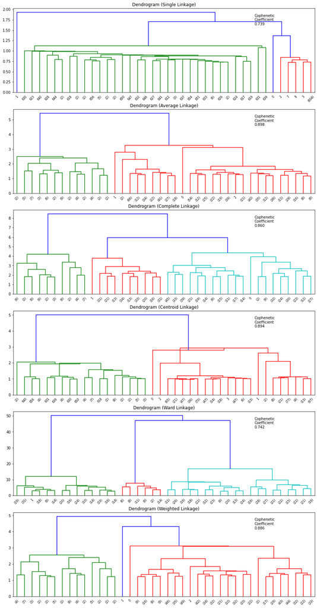

```python
# List of all linkage methods to check
methods = ['single',
           'average',
           'complete',
           'centroid',
           'ward',
          'weighted']

# Calculate the pairwise distance form the dataset to be used in the cophenetic correlation calculation
#pw_distance = pdist(credit_scaled)

# Create a subplot image
fig, axs = plt.subplots(len(methods), 1, figsize=(15, 30))

# Enumerate through the list of all methods above
# Get linkage, plot dendrogram, calculate cophenetic coefficient
for i, method in enumerate(methods):

    Z = linkage(subset_scaled_df, metric='euclidean', method=method)

    dendrogram(Z,
               truncate_mode='lastp',  # show only the last p merged clusters
               p=40,  # show only the last p merged clusters
               ax=axs[i]);
    axs[i].set_title(f'Dendrogram ({method.capitalize()} Linkage)')
    coph_corr, coph_dist = cophenet(Z, pdist(subset_scaled_df))
    axs[i].annotate(f'Cophenetic\nCoefficient\n{coph_corr:0.3f}',
                    (0.80, 0.80),
                    xycoords='axes fraction')
    compare.append([method, coph_corr])
```

### Final dendogram with average linkage method

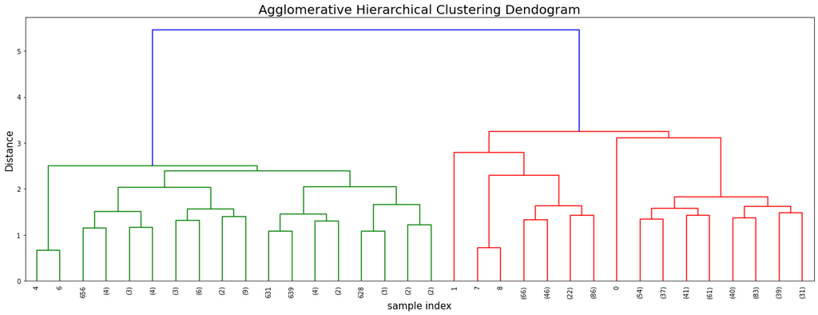

```python
plt.figure(figsize=(18, 7))
plt.title('Agglomerative Hierarchical Clustering Dendogram', {'fontsize':20})
plt.xlabel('sample index', {'fontsize':15})
plt.ylabel('Distance', {'fontsize':15})
Z = linkage(subset_scaled_df, metric='euclidean', method='average')
dendrogram(Z,leaf_rotation=90,p=5,color_threshold=4,leaf_font_size=10,truncate_mode='level')
plt.tight_layout()
```

**Observations**

- From the above dendogram based on euclidean distance and average linkage method, the optimal number of clusters seems to be two.

### Hierarchical clustering with 2 clusters

```python
df_Hierar_2 = df.copy()
```

```python
df_Hierar_2['Hierarchical_segments'] = fcluster(Z, t=2, criterion='maxclust')
```

```python
 # Rearranging cluster numbering based on average credit limit ranking
df_Hierar_2['Hierarchical_segments'] = df_Hierar_2['Hierarchical_segments'].map({1:2, 2:1})
Hierarchical_clusters_2 = df_Hierar_2.groupby('Hierarchical_segments').mean()
Hierarchical_clusters_2['count_in_each_segment'] = df_Hierar_2.groupby('Hierarchical_segments')['Avg_Credit_Limit'].count().values
Hierarchical_clusters_2
```

| Hierarchical_segments | Avg_Credit_Limit | Total_Credit_Cards | Total_visits_bank | Total_visits_online | Total_calls_made | count_in_each_segment |
| --- | --- | --- | --- | --- | --- | --- |
| 1 | 25847.540984 | 4.37541 | 2.55082 | 1.92623 | 3.788525 | 610 |
| 2 | 141040.000000 | 8.74000 | 0.60000 | 10.90000 | 1.080000 | 50 |

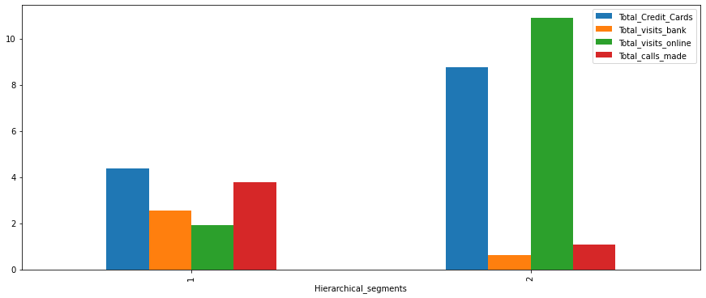

```python
Hierarchical_clusters_2.iloc[:,1:-1].plot.bar(figsize=(15,6));
```

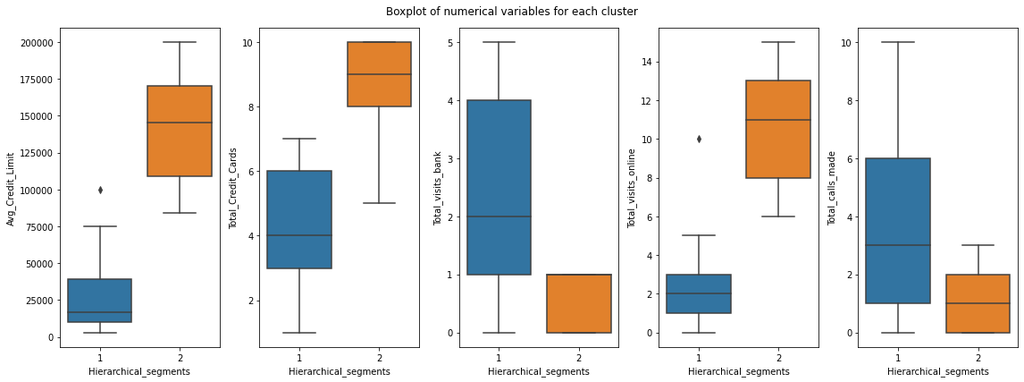

```python
fig, axes = plt.subplots(1, 5,  figsize=(16, 6))
fig.suptitle('Boxplot of numerical variables for each cluster')
for i in range(5):
    sns.boxplot(ax=axes[i],y=df_Hierar_2.iloc[:,i],x=df_Hierar_2['Hierarchical_segments'])
fig.tight_layout(pad=1)
```

**Insights**

Customers can be grouped into 2 clusters.

- Cluster 1 (610 customers) :
  - The credit limit for this group of customers is in the low range with an average of 25,847.
  - The number of credit card for this group of customers is low with most customers having between 3 and 6 credit cards.
  - The number of visits to the bank is high with most customers making between 1 and 4 visits to the bank.
  - The number of visits online remains limited with most customers making between not more than 3 visits online.
  - The number of phone calls is high with most customers in this group making at least 1 phone call and some up to 10 phone calls.
- Cluster 2 (50 customers):
  - The credit limit for this group of customers is very high with an average of 141,040.
  - The number of credit card for this group of customers is also high with 75% of customers in this group having at least 5 credit cards.
  - The number of visits to the bank is low not exceeding 1 visit to the bank.
  - On the contrary, the number of visits online is very high with 75% of customers making at least 8 visits online.
  - The number of phone calls remains low with most customers making less than 2 phone calls.

### Hierarchical clustering with 3 clusters (optional for K-means comparison only)

```python
df_Hierar_3 = df.copy()
```

```python
df_Hierar_3['Hierarchical_segments'] = fcluster(Z, t=3, criterion='maxclust')
```

```python
# Rearranging cluster numbering based on average credit limit ranking
df_Hierar_3['Hierarchical_segments'] = df_Hierar_3['Hierarchical_segments'].map({1:3, 2:1, 3:2})
Hierarchical_clusters_3 = df_Hierar_3.groupby('Hierarchical_segments').mean()
Hierarchical_clusters_3['count_in_each_segment'] = df_Hierar_3.groupby('Hierarchical_segments')['Avg_Credit_Limit'].count().values
Hierarchical_clusters_3
```

| Hierarchical_segments | Avg_Credit_Limit | Total_Credit_Cards | Total_visits_bank | Total_visits_online | Total_calls_made | count_in_each_segment |
| --- | --- | --- | --- | --- | --- | --- |
| 1 | 12197.309417 | 2.403587 | 0.928251 | 3.560538 | 6.883408 | 223 |
| 2 | 33713.178295 | 5.511628 | 3.485788 | 0.984496 | 2.005168 | 387 |
| 3 | 141040.000000 | 8.740000 | 0.600000 | 10.900000 | 1.080000 | 50 |

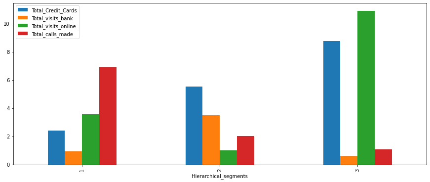

```python
Hierarchical_clusters_3.iloc[:,1:-1].plot.bar(figsize=(15,6));
```

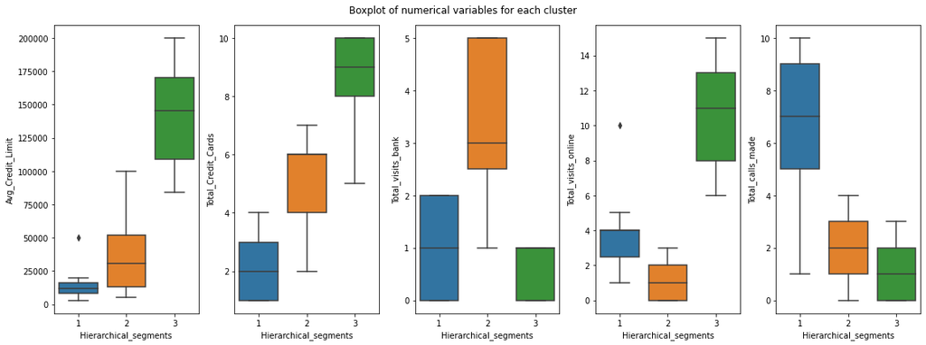

```python
fig, axes = plt.subplots(1, 5,  figsize=(16, 6))
fig.suptitle('Boxplot of numerical variables for each cluster')
for i in range(5):
    sns.boxplot(ax=axes[i],y=df_Hierar_3.iloc[:,i],x=df_Hierar_3['Hierarchical_segments'])
fig.tight_layout(pad=1)
```

# Calculate average silhouette score for both clustering methods.

```python
sil_score_Kmeans = []
sil_score_Hierar = []
cluster_list = list(range(2,11))
for n in cluster_list:

    kmeans = KMeans(n_clusters=n)
    pred_kmeans = kmeans.fit_predict((subset_scaled_df))
    kmean_score = silhouette_score(subset_scaled_df, pred_kmeans)
    sil_score_Kmeans.append(kmean_score)

    pred_hierar = fcluster(Z, t=n, criterion='maxclust')
    hierar_score = silhouette_score(subset_scaled_df, pred_hierar)
    sil_score_Hierar.append(hierar_score)
```

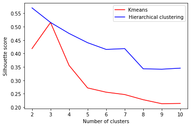

```python
plt.plot(cluster_list,sil_score_Kmeans, label='Kmeans', color='r')
plt.plot(cluster_list,sil_score_Hierar, label='Hierarchical clustering', color='b')
plt.xlabel('Number of clusters')
plt.ylabel('Silhouette score')
plt.legend()
plt.show()
```

```python
# Silhouette score comparison for 3 clusters
sil_score = []
methods = ['KMeans with 3 clusters', 'Hierarchical clustering with 3 clusters']
preds = [df_Kmean['K_means_segments'], df_Hierar_3['Hierarchical_segments']]
for pred, method in zip(preds, methods):
    score = silhouette_score(subset_scaled_df, pred)
    sil_score.append(score)
    print("Silouhette score with {} is {:.4f}".format(method, score))
```

```
Silouhette score with KMeans with 3 clusters is 0.5157
Silouhette score with Hierarchical clustering with 3 clusters is 0.5159
```

**Observations**

- From the plot above, we can say that the hierarchical clustering method (with average linkage and Euclidean distance) is better than the K-Means clustering method.
- The optimal number of clusters is 2 for the hierarchical clustering method while it is 3 for the K-means method.

### Slihouette plots

#### K-means with 3 clusters

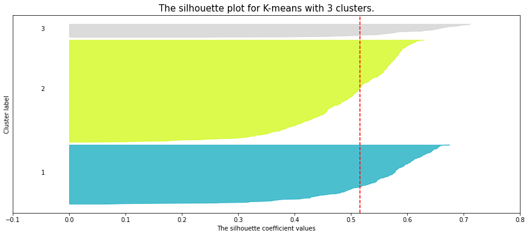

```python
#Silhouette plot for K-means with 3 clusters
plt.figure(figsize=(15,6))
cluster_labels = df_Kmean['K_means_segments']
silhouette_avg = silhouette_score(subset_scaled_df, cluster_labels)
sample_silhouette_values = silhouette_samples(subset_scaled_df, cluster_labels)
y_lower = 10
for i in range(1,4):
    # Aggregate the silhouette scores for samples belonging to
    # cluster i, and sort them
    ith_cluster_silhouette_values = \
    sample_silhouette_values[cluster_labels == i]
    ith_cluster_silhouette_values.sort()

    size_cluster_i = ith_cluster_silhouette_values.shape[0]
    y_upper = y_lower + size_cluster_i

    color = cm.nipy_spectral(float(i) / 3)
    plt.fill_betweenx(np.arange(y_lower, y_upper),
                          0, ith_cluster_silhouette_values,
                          facecolor=color, edgecolor=color, alpha=0.7)

    # Label the silhouette plots with their cluster numbers at the middle
    plt.text(-0.05, y_lower + 0.5 * size_cluster_i, str(i))

    # Compute the new y_lower for next plot
    y_lower = y_upper + 10  # 10 for the 0 samples

plt.title("The silhouette plot for K-means with 3 clusters.", {'fontsize': 15})
plt.xlabel("The silhouette coefficient values")
plt.ylabel("Cluster label")

# The vertical line for average silhouette score of all the values
plt.axvline(x=silhouette_avg, color="red", linestyle="--")

plt.yticks([])  # Clear the yaxis labels / ticks
plt.xticks(np.arange(-0.1,0.9,0.1))
plt.show()
```

#### Hierarchical clustering with 2 clusters

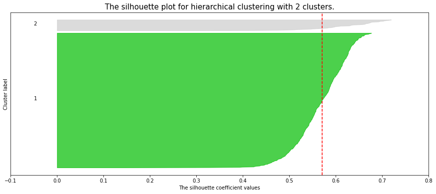

```python
#Silhouette plot for hierarchical clustering with 2 clusters
plt.figure(figsize=(15,6))
cluster_labels = df_Hierar_2['Hierarchical_segments']
silhouette_avg = silhouette_score(subset_scaled_df, cluster_labels)
sample_silhouette_values = silhouette_samples(subset_scaled_df, cluster_labels)
y_lower = 10
for i in range(1,3):
    # Aggregate the silhouette scores for samples belonging to
    # cluster i, and sort them
    ith_cluster_silhouette_values = \
    sample_silhouette_values[cluster_labels == i]
    ith_cluster_silhouette_values.sort()

    size_cluster_i = ith_cluster_silhouette_values.shape[0]
    y_upper = y_lower + size_cluster_i

    color = cm.nipy_spectral(float(i) / 2)
    plt.fill_betweenx(np.arange(y_lower, y_upper),
                          0, ith_cluster_silhouette_values,
                          facecolor=color, edgecolor=color, alpha=0.7)

    # Label the silhouette plots with their cluster numbers at the middle
    plt.text(-0.05, y_lower + 0.5 * size_cluster_i, str(i))

    # Compute the new y_lower for next plot
    y_lower = y_upper + 10  # 10 for the 0 samples

plt.title("The silhouette plot for hierarchical clustering with 2 clusters.", {'fontsize': 15})
plt.xlabel("The silhouette coefficient values")
plt.ylabel("Cluster label")

# The vertical line for average silhouette score of all the values
plt.axvline(x=silhouette_avg, color="red", linestyle="--")

plt.yticks([])  # Clear the yaxis labels / ticks
plt.xticks(np.arange(-0.1,0.9,0.1))
plt.show()
```

# K-means vs Hierarchical clusters.

### Comparison for 3 clusters

```python
K_means_clusters
```

| K_means_segments | Avg_Credit_Limit | Total_Credit_Cards | Total_visits_bank | Total_visits_online | Total_calls_made | count_in_each_segment |
| --- | --- | --- | --- | --- | --- | --- |
| 1 | 12174.107143 | 2.410714 | 0.933036 | 3.553571 | 6.870536 | 224 |
| 2 | 33782.383420 | 5.515544 | 3.489637 | 0.981865 | 2.000000 | 386 |
| 3 | 141040.000000 | 8.740000 | 0.600000 | 10.900000 | 1.080000 | 50 |

```python
Hierarchical_clusters_3
```

| Hierarchical_segments | Avg_Credit_Limit | Total_Credit_Cards | Total_visits_bank | Total_visits_online | Total_calls_made | count_in_each_segment |
| --- | --- | --- | --- | --- | --- | --- |
| 1 | 12197.309417 | 2.403587 | 0.928251 | 3.560538 | 6.883408 | 223 |
| 2 | 33713.178295 | 5.511628 | 3.485788 | 0.984496 | 2.005168 | 387 |
| 3 | 141040.000000 | 8.740000 | 0.600000 | 10.900000 | 1.080000 | 50 |

```python
df_Kmean[df_Kmean['K_means_segments'] != df_Hierar_3['Hierarchical_segments']]
```

| Sl_No | Avg_Credit_Limit | Total_Credit_Cards | Total_visits_bank | Total_visits_online | Total_calls_made | K_means_segments |
| --- | --- | --- | --- | --- | --- | --- |
| 314 | 7000 | 4 | 2 | 2 | 4 | 1 |

**Observations**

- The two clustering methods, although completely different in the way they operate, give almost identical results for a number of clusters equal to 3.
- They only differ for one customer (Sl_No = 314) grouped into cluster 1 for K_means and cluster 2 for hierarchical clustering.

### Hierarchical clustering for 2 clusters

```python
Hierarchical_clusters_2
```

| Hierarchical_segments | Avg_Credit_Limit | Total_Credit_Cards | Total_visits_bank | Total_visits_online | Total_calls_made | count_in_each_segment |
| --- | --- | --- | --- | --- | --- | --- |
| 1 | 25847.540984 | 4.37541 | 2.55082 | 1.92623 | 3.788525 | 610 |
| 2 | 141040.000000 | 8.74000 | 0.60000 | 10.90000 | 1.080000 | 50 |

As we could see from the dendogram, if we choose to go with 2 clusters instead of 3, the first two clusters seen previously would be merged into cluster 1 while cluster 2 remains identical to former cluster 3.

# Conclusion and Business Recommendations

These 660 customers can be split into 2 or 3 categories depending on the clustering method (K-means or hierarchical clustering).

- Cluster 1 (223 customers) consists of customers with a low credit limit (12,174 on average). These customers have less credit cards and but call the bank very frequently. They are the less profitable customers for the bank at the moment. These customers should be incentivized to buy additional credit card services through customized marketing policies.
- Cluster 3 (50 customers) consists of customers with a high credit limit (141,040 on average). These customers have many credit cards, do not visit or call the bank frequently and use online services. They are the most valuable customers for the bank.
- Compared to cluster 1 and 3, cluster 2 (387 customers) represents a kind of intermediate category. If we were to choose only 2 clusters, this cluster would be merged with cluster 1. These customers have a medium credit limit (33,713 on average). They distinguish from the other groups of customers based on the high number of visits to the bank and low internet banking usage. This group of customer would perhaps benefit from staff guidance in order to become more familiar with the internet banking system.